# Local links and wider roles

What payments between industries can and can’t show about supply chains: three industries in Yorkshire and the Humber

24 November 2026

## The chain in our heads

A supply chain passes goods and services from one business to the next. Each adds something, and it ends with someone who uses the result.

- **A middle link** buys from one kind of business and sells on to another.
- **An end** is where the chain starts, or where what was made is finally used.

This deck asks how much of that we can see in payments between industries.

## What the data is

Payments between businesses, by industry and region, each month. Turn a payment round and it stands for goods or a service going the other way.

- The page can draw either. This deck uses **goods and services**, because that is what a chain is made of.
- **Services count as much as goods.** Rent is the use of a building and insurance is cover. Both go into production, even though nothing travels down a road.
- **It is still an inference.** The data records that a payment was made, not what for. Some aren’t purchases at all: taxes, subsidies, dividends. ONS says it can’t yet tell the types apart.

## What the data leaves out

Of each £1 that industries in Yorkshire and the Humber were paid, only about 10p came from another industry in the region. That 10p is the network the page draws.

[figure not shown]

- **Not in the data at all:** households, and anything bought from or sold abroad.
- **In the data but not placed:** payers whose industry isn’t recorded, and public administration, which has no region.
- **Why so many have no industry:** ONS finds an account’s industry and its address by matching its name to Companies House, or to lists of public bodies. No match means neither: of what such payers send to the region, 96% comes from payers with no region either.

## The page

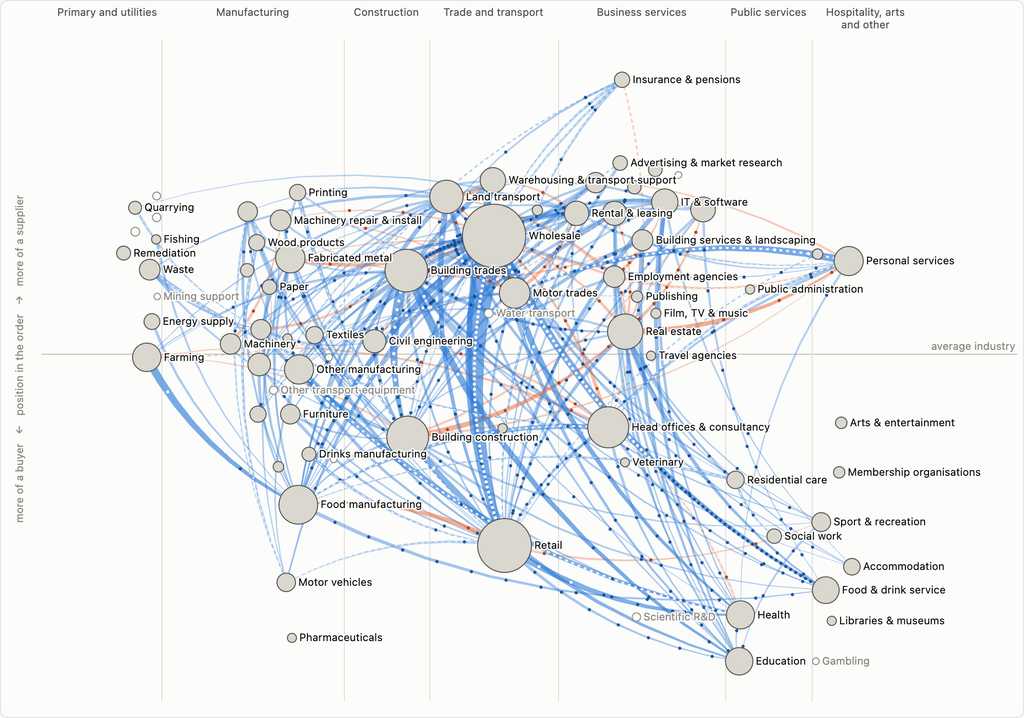

Each circle is an industry. Each link is goods or services passing between two of them.

Open this view

## A test for “in a chain”

Take everything an industry buys from and sells to the other industries in its region. Each pound of it is one of three things.

[figure not shown]

**No cut-off separates them. Trade is matched up, one partner at a time.** Buy £10 from an industry and sell it £4: £4 each way is two-way, and the £6 left over runs one way. That one-way buying is set against one-way selling to *other* industries. What matches is passed along. The rest is an end of the line.

The three always add up to the whole. Nothing here depends on where the page puts the industry.

## The three industries, tested

[figure not shown]

- **Other manufacturing** passes along nearly half of its trade with other industries here. A middle link.
- **Education** passes along almost nothing. It buys here, and those it provides for mostly aren’t in the data.
- **Wholesale** passes along 7%. On this test it is where goods *start*.

Trade with other industries inside Yorkshire and the Humber, by what was paid, January 2019 to September 2026. Test 23.

## Drawing a chain, one pair at a time

The test gives a figure. To show *which* industries, the page traces a chain from the one that is pinned.

[figure not shown]

1. **One link a pair.** Two-way trade is netted off first, as in the test. What is left between two industries runs one way.
2. **Keep the large links.** A supplier stays if it provides a tenth or more of the industry’s one-way buying. A customer stays if it takes a tenth or more of its one-way selling.
3. **Once more, then stop.** The same rule is applied from each industry reached. Two steps each way.

## The test and the trace

Two tools, and they answer different questions.

|  | The test | The trace |
| --- | --- | --- |
| **It answers** | How much does this industry pass along? | Which industries is it linked to? |
| **It works on** | The industry’s totals | One pair of industries at a time |
| **Its cut-off** | None: trade is matched up | A tenth of one-way buying or selling |

- **Pairs are all the data has.** No payment is tied to any other payment, so every chain of three is an inference.
- **Each link is the whole one-way flow between two industries,** not the part that carries on along the chain.
- **Step two is looser than step one.** It shows a supplier’s main suppliers, whoever those supplies were for.

## Other manufacturing: who it trades with

More than half its jobs here are in medical and dental instruments.

[figure not shown]

It buys from metals, plastics and wholesale. It sells to health, shops and builders. Different industries on each side: that is what a middle link looks like.

## Other manufacturing’s chain: step one

Its one-way buying and selling, partner by partner. A link is kept if it is a tenth or more of the total.

[figure not shown]

Two suppliers and three customers clear the line. Rubber & plastics misses it at 9.97%. The links kept carry 27% of its one-way buying and 72% of its one-way selling. The other 65 links are left out.

## Other manufacturing’s chain: step two

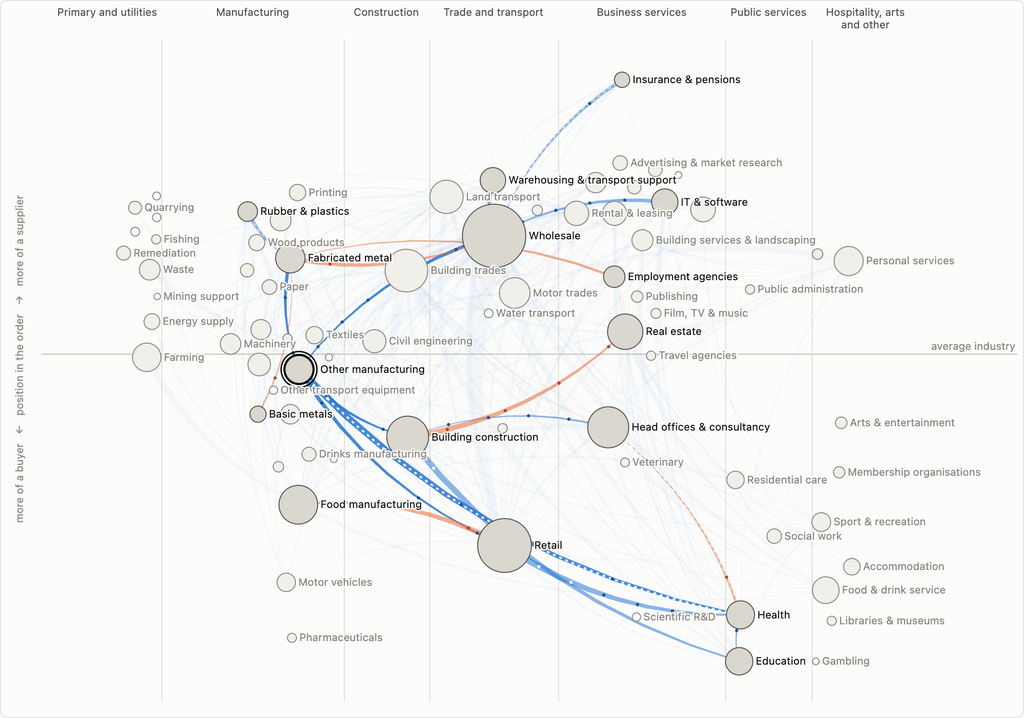

The same rule again, from each of the five. This is the chain as the page draws it.

- **Above its suppliers, theirs.** Rubber and plastics, basic metals and employment agencies supply fabricated metal. Warehousing, fabricated metal, IT and insurance supply wholesale.
- **Below its customers, theirs.** Head offices, real estate, education and food manufacturing.

Step two is about *them*. Wholesale buys insurance for all its trade, not for what it sells to other manufacturing.

One reading that holds together: metal, to metal parts, to instruments, to hospitals.

Open this view

## The national table agrees

The UK’s input-output table is built from surveys and business accounts, not from payments. It has other manufacturing selling most to health and building construction, and buying most from wholesale, retail, fabricated metal, land transport and basic metals.

[figure not shown]

Same partners, and a middle link on both. For this industry the payments show the real thing.

## Cautions, even here

98% or 75%

of its trade runs down the page. The first figure is with one net link drawn for each pair of industries, as the page does. The second counts both directions. The typical industry here has 87% and 70%.

48%

of its trade here is two-way: bought from an industry that buys back. The picture hides this, because a pair gets one link.

58%

of what the industry makes, nationally, is sold abroad. Payments between UK businesses can’t see any of that.

So even the cleanest case is a local stretch of something larger.

## Education: where chains finish

It buys £20m a month from other industries here, and sells them £2.1m.

[figure not shown]

Builders, IT firms, wholesalers and building services supply it. Almost nothing comes back. On the test it is a buyer end: 81% of its trade here.

## Its chain on the page

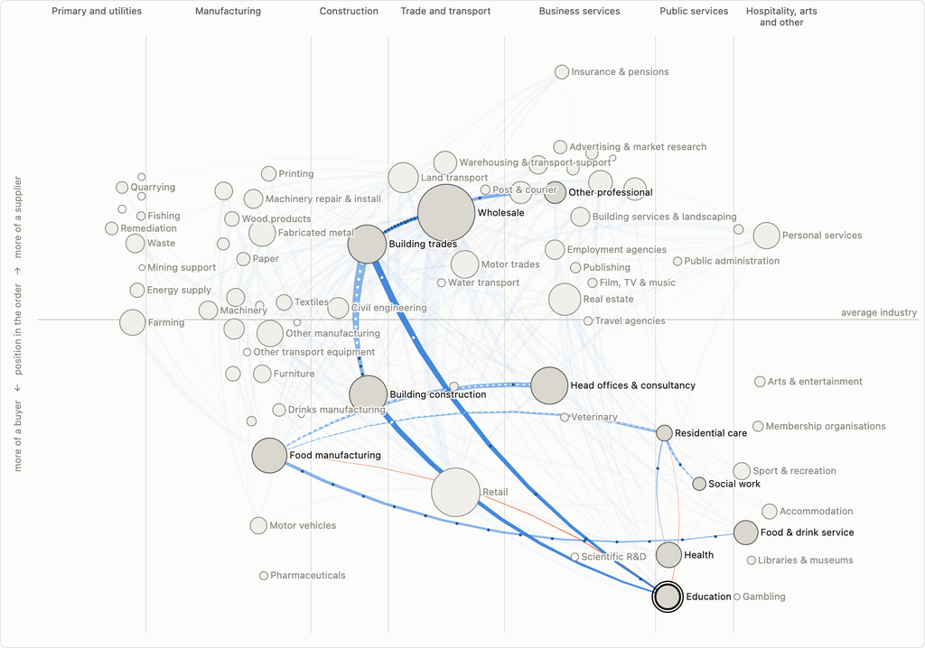

Education is at the bottom: the last buyer.

- **Above it, its suppliers:** building trades and building construction.
- **Above them, theirs:** wholesale and professional services.
- **Below it:** next to nothing.

One of the region’s largest chains finishes here: building trades, to building construction, to education.

Open this view

## Why education is an end

Nationally, this is who education provides for:

61%

government, buying on behalf of pupils and students

14%

households, paying directly

17%

other businesses

7%

abroad

- **Households aren’t in the data.** Public administration is, but with no region, so its payments can’t be placed.
- **So the chain stops at education because its customers are missing,** not because nobody uses what it does.
- **Here the “end” is right in spirit.** Teaching is where these chains finish. What the chart gets wrong is its size: education shows by what it buys, not by what it provides.

## Wholesale: the puzzle

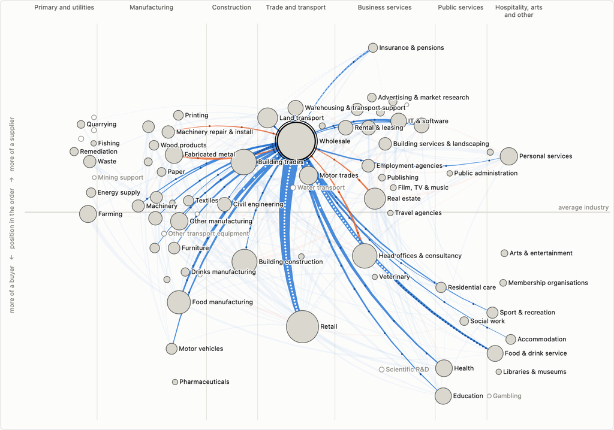

In anyone’s picture of a chain, wholesale is the middle. In the national table it is too.

53%

passed along, nationally

7%

passed along, here

On the page, goods pour out of it and far less goes in.

Open this view

## Where do its goods come from?

£142m

a month sold to other industries in the region

£47m

a month bought from them

18%

of what it buys from UK industries is bought inside the region

?

bought from abroad. Imports aren’t in the data at all

- Passing along needs both an in and an out **inside the region**. Wholesale has the out.
- Most of what it sells here was bought somewhere the chart can’t see.
- It is a supplier end in all 12 regions.

## Does counting the rest of the UK fix it?

The obvious repair: treat industries elsewhere in the UK as partners too, so that goods bought in Leeds from a maker in Birmingham count as coming in.

[figure not shown]

**No.** Passed along goes from 7% to 12%, against 53% in the national table. Across the 12 regions it rises in 7 and falls in 5.

Wholesale, Yorkshire and the Humber. Test 24.

## Why not

- **Much of what wholesale buys isn’t in the data.** Imports are missing, and so are payees whose industry isn’t recorded. Even UK-wide it sells far more to industries than it buys from them.
- **Across whole industries, its trade nets off.** UK-wide, 58% of it is two-way: the industries it buys from are largely the ones it sells to.
- **The rest of the UK is the weaker half of the data.** More of it is hidden by ONS, and a payment is placed at a firm’s registered office, which matters most when it crosses a regional line.

So the gap between 7% and 53% is mostly about what payments are, not about where the region’s edge falls.

## Three industries, three blind spots

|  | What the payments show here | What they miss | Where the missing part is |
| --- | --- | --- | --- |
| **Other manufacturing** | A middle link: metals in, health out | 58% of what it makes goes abroad | Outside the data |
| **Education** | A buyer end: it buys here and sells almost nothing | Who it provides for: government and households | Outside the data, or in it with no region |
| **Wholesale** | A supplier end: goods seem to start with it | Where its goods come from. Nationally it is a middle link | Other regions and abroad |

The local links are real in all three. What differs is how much of the industry’s work they are.

## Every industry: here against the national table

[figure not shown]

They agree only loosely (a rank correlation of 0.30; 1 would be the same order). Most industries pass along more nationally than the payments show here.

## Who each sells to, nationally

[figure not shown]

This is the wider role: an exporter, a public service, and a trader that sells half to other businesses and a third abroad. None of it is in the payments.

UK input-output analytical tables, 2019. “Everything else” is what the other four don’t cover, such as investment. Test 19.

## The principle

Two different questions, and the page should keep them apart:

**What does this industry do with other industries here?**

The payments answer this well. Links, direction, who trades with whom, how it changes month by month.

**What is this industry’s role in the economy?**

The payments can’t answer this. The national tables can, though not for one region or one year at a time.

Show both, side by side. Don’t try to make the first yield the second.

## What the page could do next

1. **Say why an industry is an end,** in its side panel: “82% of what it buys from UK industries is bought outside the region.” Needs nothing new.
2. **Let a traced chain leave the region.** Where a trail reaches an industry that mostly buys or sells elsewhere, draw a short stub towards the edge with the share on it. Needs nothing new.
3. **Put the national role beside the local one.** For wholesale: here 7% passed along, nationally 53%; nationally 33% of what it sells goes abroad. A small lookup, no change to the payments data.

A fourth idea, a chain measure that counts the rest of the UK, was tested and doesn’t work.

## What no route recovers

- **Imports and exports.** The data’s regions are the twelve regions of the UK and “unknown”. There is no abroad.
- **Households.** They buy most of what the economy makes and aren’t in it.
- **Where goods physically go.** A payment sits at a firm’s registered office. ONS calls this the headquarter effect.
- **What was bought.** A payment is not always a purchase.

These are limits of the payments, not of the page. They are the reason to show the national tables beside it.

## Sources and method

- **Payments:** Office for National Statistics, [Industry-to-industry payment flows by region, UK](https://www.ons.gov.uk/economy/economicoutputandproductivity/output/datasets/industrytoindustrypaymentflowsbyregionuk), from Pay.UK data, January 2019 to September 2026. Official statistics in development. Contains public sector information licensed under the Open Government Licence v3.0.
- **How ONS builds it:** its [article](https://www.ons.gov.uk/economy/economicoutputandproductivity/output/articles/industrytoindustrypaymentflowsuk/2019to2025) and [methodology note](https://www.ons.gov.uk/economy/economicoutputandproductivity/output/methodologies/industrytoindustrymonthlypaymentsukqmi) of January 2026.
- **National table:** ONS input-output analytical tables, 2019.
- **Jobs:** Business Register and Employment Survey, 2023.
- **The page:** payment flows for Yorkshire and the Humber.
- **The tests behind every figure here:** tests 19, 22, 23, 23b, 24 and 25 in the page’s `tests` folder, written up in sections 12 to 14 of its plan.

Goods and services are inferred by turning each payment round. Figures are for trade between industries where both the industry and the region are recorded, with banks and other intermediaries left out. The charts are worked out from the tests’ outputs each time the deck is built (`plan/chains_deck_plan.md`).